# 10 Tutorial

# Preamble

## Load Packages

```r
load.pac <- function() {

  if(require("pacman")){
    library(pacman)
  }else{
    install.packages("pacman")
    library(pacman)
  }

  pacman::p_load(xts, sp, gstat, ggplot2, rmarkdown, reshape2, ggmap, wesanderson,
                 parallel, dplyr, plotly, tidyverse, reticulate, UsingR, Rmpfr, latex2exp,
                 mise, GGally, usmap)

#  devtools::install_github("tidyverse/tidyverse")
}

load.pac()
mise()
```

## Load Data

```r
(adult  <- read.csv(file = "./10_data/AdultDataSet/adult.data")) %>%  head()
```

|  | Age | Workclass | Wage | Education | Years.of.Education | Marital.Status | Occupation | Relationship | Race | Sex | Capital.Gain | Capital.Loss | Hours.Per.Week | Native.Country | Income.Threshold |
| --- | --- | --- | --- | --- | --- | --- | --- | --- | --- | --- | --- | --- | --- | --- | --- |
| 1 | 39 | State-gov | 77516 | Bachelors | 13 | Never-married | Adm-clerical | Not-in-family | White | Male | 2174 | 0 | 40 | United-States | <=50K |
| 2 | 50 | Self-emp-not-inc | 83311 | Bachelors | 13 | Married-civ-spouse | Exec-managerial | Husband | White | Male | 0 | 0 | 13 | United-States | <=50K |
| 3 | 38 | Private | 215646 | HS-grad | 9 | Divorced | Handlers-cleaners | Not-in-family | White | Male | 0 | 0 | 40 | United-States | <=50K |
| 4 | 53 | Private | 234721 | 11th | 7 | Married-civ-spouse | Handlers-cleaners | Husband | Black | Male | 0 | 0 | 40 | United-States | <=50K |
| 5 | 28 | Private | 338409 | Bachelors | 13 | Married-civ-spouse | Prof-specialty | Wife | Black | Female | 0 | 0 | 40 | Cuba | <=50K |
| 6 | 37 | Private | 284582 | Masters | 14 | Married-civ-spouse | Exec-managerial | Wife | White | Female | 0 | 0 | 40 | United-States | <=50K |

```r
(aus    <- read.table(file = "./10_data/Australian/australian.dat",  header = TRUE)) %>%  head()
```

|  | X1 | X22.08 | X11.46 | X2 | X4 | X4.1 | X1.585 | X0 | X0.1 | X0.2 | X1.1 | X2.1 | X100 | X1213 | X0.3 |
| --- | --- | --- | --- | --- | --- | --- | --- | --- | --- | --- | --- | --- | --- | --- | --- |
| 1 | 0 | 22.67 | 7.000 | 2 | 8 | 4 | 0.165 | 0 | 0 | 0 | 0 | 2 | 160 | 1 | 0 |
| 2 | 0 | 29.58 | 1.750 | 1 | 4 | 4 | 1.250 | 0 | 0 | 0 | 1 | 2 | 280 | 1 | 0 |
| 3 | 0 | 21.67 | 11.500 | 1 | 5 | 3 | 0.000 | 1 | 1 | 11 | 1 | 2 | 0 | 1 | 1 |
| 4 | 1 | 20.17 | 8.170 | 2 | 6 | 4 | 1.960 | 1 | 1 | 14 | 0 | 2 | 60 | 159 | 1 |
| 5 | 0 | 15.83 | 0.585 | 2 | 8 | 8 | 1.500 | 1 | 1 | 2 | 0 | 2 | 100 | 1 | 1 |
| 6 | 1 | 17.42 | 6.500 | 2 | 3 | 4 | 0.125 | 0 | 0 | 0 | 0 | 2 | 60 | 101 | 0 |

```r
(mob   <- read.csv(file = "./10_data/Datamobile Data Set/imports-85.data")) %>% head()
```

|  | symboling | normalized.losses | make | fuel.type | aspiration | num.of.doors | body.style | drive.wheels | engine.location | wheel.base | length | width | height | curb.weight | engine.type | num.of.cylinders | engine.size | fuel.system | bore | stroke | compression.ratio | horsepower | peak.rpm | city.mpg | highway.mpg | price |
| --- | --- | --- | --- | --- | --- | --- | --- | --- | --- | --- | --- | --- | --- | --- | --- | --- | --- | --- | --- | --- | --- | --- | --- | --- | --- | --- |
| 1 | 3 | ? | alfa-romero | gas | std | two | convertible | rwd | front | 88.6 | 168.8 | 64.1 | 48.8 | 2548 | dohc | four | 130 | mpfi | 3.47 | 2.68 | 9.0 | 111 | 5000 | 21 | 27 | 13495 |
| 2 | 3 | ? | alfa-romero | gas | std | two | convertible | rwd | front | 88.6 | 168.8 | 64.1 | 48.8 | 2548 | dohc | four | 130 | mpfi | 3.47 | 2.68 | 9.0 | 111 | 5000 | 21 | 27 | 16500 |
| 3 | 1 | ? | alfa-romero | gas | std | two | hatchback | rwd | front | 94.5 | 171.2 | 65.5 | 52.4 | 2823 | ohcv | six | 152 | mpfi | 2.68 | 3.47 | 9.0 | 154 | 5000 | 19 | 26 | 16500 |
| 4 | 2 | 164 | audi | gas | std | four | sedan | fwd | front | 99.8 | 176.6 | 66.2 | 54.3 | 2337 | ohc | four | 109 | mpfi | 3.19 | 3.40 | 10.0 | 102 | 5500 | 24 | 30 | 13950 |
| 5 | 2 | 164 | audi | gas | std | four | sedan | 4wd | front | 99.4 | 176.6 | 66.4 | 54.3 | 2824 | ohc | five | 136 | mpfi | 3.19 | 3.40 | 8.0 | 115 | 5500 | 18 | 22 | 17450 |
| 6 | 2 | ? | audi | gas | std | two | sedan | fwd | front | 99.8 | 177.3 | 66.3 | 53.1 | 2507 | ohc | five | 136 | mpfi | 3.19 | 3.40 | 8.5 | 110 | 5500 | 19 | 25 | 15250 |

```r
(house <- read.table(file = "./10_data/Housing/housing.data", header = TRUE) ) %>% head()
```

|  | CRIM | ZN | INDUS | CHAS | NOX | RM | AGE | DIS | RAD | TAX | PTRATIO | B | LSTAT | MEDV |
| --- | --- | --- | --- | --- | --- | --- | --- | --- | --- | --- | --- | --- | --- | --- |
| 1 | 0.00632 | 18 | 2.31 | 0 | 0.538 | 6.575 | 65.2 | 4.0900 | 1 | 296 | 15.3 | 396.90 | 4.98 | 24.0 |
| 2 | 0.02731 | 0 | 7.07 | 0 | 0.469 | 6.421 | 78.9 | 4.9671 | 2 | 242 | 17.8 | 396.90 | 9.14 | 21.6 |
| 3 | 0.02729 | 0 | 7.07 | 0 | 0.469 | 7.185 | 61.1 | 4.9671 | 2 | 242 | 17.8 | 392.83 | 4.03 | 34.7 |
| 4 | 0.03237 | 0 | 2.18 | 0 | 0.458 | 6.998 | 45.8 | 6.0622 | 3 | 222 | 18.7 | 394.63 | 2.94 | 33.4 |
| 5 | 0.06905 | 0 | 2.18 | 0 | 0.458 | 7.147 | 54.2 | 6.0622 | 3 | 222 | 18.7 | 396.90 | 5.33 | 36.2 |
| 6 | 0.02985 | 0 | 2.18 | 0 | 0.458 | 6.430 | 58.7 | 6.0622 | 3 | 222 | 18.7 | 394.12 | 5.21 | 28.7 |

# Question 1 and 2

## Adult Data

First investigate the Features

```r
names(adult)
```

```
 [1] "Age"                "Workclass"          "Wage"               "Education"          "Years.of.Education" "Marital.Status"     "Occupation"         "Relationship"       "Race"
[10] "Sex"                "Capital.Gain"       "Capital.Loss"       "Hours.Per.Week"     "Native.Country"     "Income.Threshold"
```

Now plot the data relating to Income Threshold:

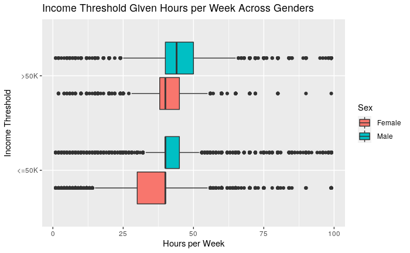

```r
ggplot(adult, aes(x = Hours.Per.Week, y = Income.Threshold, fill = Sex)) +
  geom_boxplot() +
  labs(x = "Hours per Week", y = "Income Threshold", title = "Income Threshold Given Hours per Week Across Genders")
```

this demonstrates that men tend to work longer hours and women need to work longer hours in order to earn above $50K.

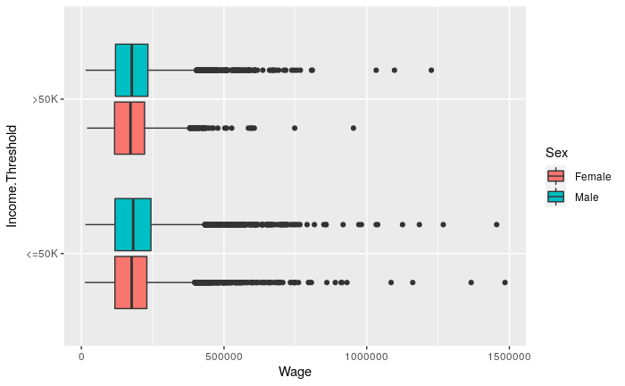

```r
ggplot(adult, aes(y = Income.Threshold, fill = Sex, x = Wage)) +
  geom_boxplot()
```

This demonstrates that wage has no bearing on Income Threshold, which is likely not true, there could be an issue with the data.

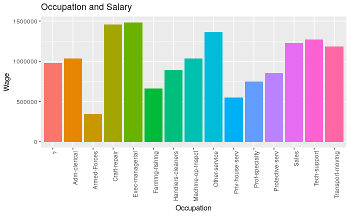

```r
ggplot(adult, aes(x = Occupation, fill = Occupation, y = Wage)) +
  geom_col(position = 'dodge') +
  theme(axis.text.x = element_text(angle = 90, hjust = 1)) +
  guides(fill = FALSE) +
  labs(title = "Occupation and Salary")
```

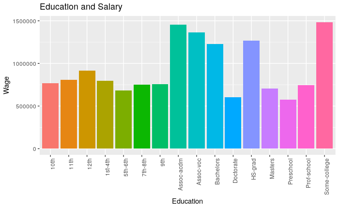

```r
ggplot(adult, aes(x = Education, fill = Education, y = Wage)) +
  geom_col(position = 'dodge') +
  theme(axis.text.x = element_text(angle = 90, hjust = 1)) +
  guides(fill = FALSE) +
  labs(title = "Education and Salary")
```

This plot suggests that the less college you complete, the more money you will earn, again, there may be something awry with this data.

## Aus Data

This data set has non descriptive features, for visual analytics this might be better because it allows for analysis without prejudice.

The best thing to do is to use a correlation plot in order to determine which features are the most significant:

```r
library(corrplot)
head(aus)
```

|  | X1 | X22.08 | X11.46 | X2 | X4 | X4.1 | X1.585 | X0 | X0.1 | X0.2 | X1.1 | X2.1 | X100 | X1213 | X0.3 |
| --- | --- | --- | --- | --- | --- | --- | --- | --- | --- | --- | --- | --- | --- | --- | --- |
| 1 | 0 | 22.67 | 7.000 | 2 | 8 | 4 | 0.165 | 0 | 0 | 0 | 0 | 2 | 160 | 1 | 0 |
| 2 | 0 | 29.58 | 1.750 | 1 | 4 | 4 | 1.250 | 0 | 0 | 0 | 1 | 2 | 280 | 1 | 0 |
| 3 | 0 | 21.67 | 11.500 | 1 | 5 | 3 | 0.000 | 1 | 1 | 11 | 1 | 2 | 0 | 1 | 1 |
| 4 | 1 | 20.17 | 8.170 | 2 | 6 | 4 | 1.960 | 1 | 1 | 14 | 0 | 2 | 60 | 159 | 1 |
| 5 | 0 | 15.83 | 0.585 | 2 | 8 | 8 | 1.500 | 1 | 1 | 2 | 0 | 2 | 100 | 1 | 1 |
| 6 | 1 | 17.42 | 6.500 | 2 | 3 | 4 | 0.125 | 0 | 0 | 0 | 0 | 2 | 60 | 101 | 0 |

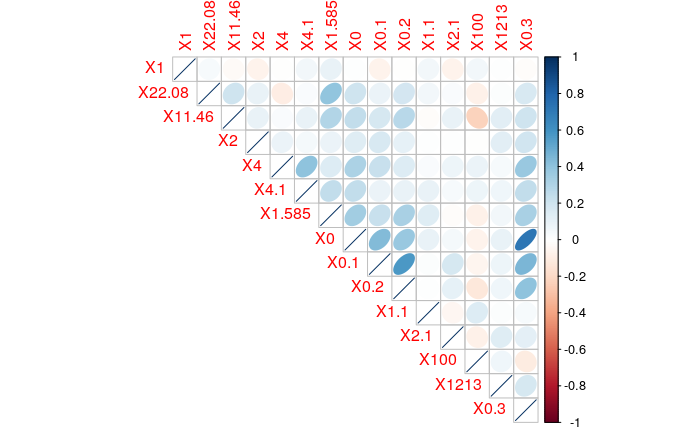

```r
cor(aus) %>% corrplot(method = 'ellipse', type = 'upper')
```

from this we can tell that `X0.3` and `X0` are highly correlated, as are `X0.1` and `X0.2`, there also appers to be weak negative correlation between `x100` and `X11.46`, these can be represented by a scatter plot to better understand the behaviour, for example:

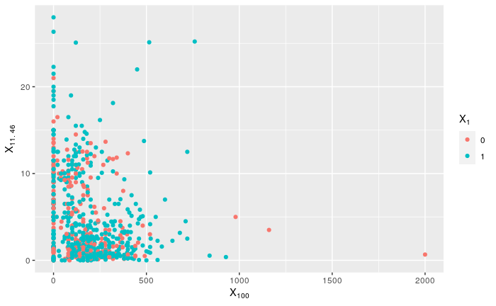

```r
ggplot(aus, aes(x = X100, y = X11.46, col = factor(X1))) +
  geom_point() +
  guides(col = guide_legend(TeX("X_1"))) +
  labs(x = TeX("X_{100}"), y = TeX("X_{11.46}"))
```

## DataMobile

The data can be inspected using `str`:

```r
str(mob)
```

```
'data.frame':   205 obs. of  26 variables:
 $ symboling        : int  3 3 1 2 2 2 1 1 1 0 ...
 $ normalized.losses: chr  "?" "?" "?" "164" ...
 $ make             : chr  "alfa-romero" "alfa-romero" "alfa-romero" "audi" ...
 $ fuel.type        : chr  "gas" "gas" "gas" "gas" ...
 $ aspiration       : chr  "std" "std" "std" "std" ...
 $ num.of.doors     : chr  "two" "two" "two" "four" ...
 $ body.style       : chr  "convertible" "convertible" "hatchback" "sedan" ...
 $ drive.wheels     : chr  "rwd" "rwd" "rwd" "fwd" ...
 $ engine.location  : chr  "front" "front" "front" "front" ...
 $ wheel.base       : num  88.6 88.6 94.5 99.8 99.4 ...
 $ length           : num  169 169 171 177 177 ...
 $ width            : num  64.1 64.1 65.5 66.2 66.4 66.3 71.4 71.4 71.4 67.9 ...
 $ height           : num  48.8 48.8 52.4 54.3 54.3 53.1 55.7 55.7 55.9 52 ...
 $ curb.weight      : int  2548 2548 2823 2337 2824 2507 2844 2954 3086 3053 ...
 $ engine.type      : chr  "dohc" "dohc" "ohcv" "ohc" ...
 $ num.of.cylinders : chr  "four" "four" "six" "four" ...
 $ engine.size      : int  130 130 152 109 136 136 136 136 131 131 ...
 $ fuel.system      : chr  "mpfi" "mpfi" "mpfi" "mpfi" ...
 $ bore             : chr  "3.47" "3.47" "2.68" "3.19" ...
 $ stroke           : chr  "2.68" "2.68" "3.47" "3.40" ...
 $ compression.ratio: num  9 9 9 10 8 8.5 8.5 8.5 8.3 7 ...
 $ horsepower       : chr  "111" "111" "154" "102" ...
 $ peak.rpm         : chr  "5000" "5000" "5000" "5500" ...
 $ city.mpg         : int  21 21 19 24 18 19 19 19 17 16 ...
 $ highway.mpg      : int  27 27 26 30 22 25 25 25 20 22 ...
 $ price            : chr  "13495" "16500" "16500" "13950" ...
```

This reveals the data are car metrics, we can then visualise different aspects of the data that might be interesting:

### Average Price per Manufacturer

```r
mob$price <- as.numeric(mob$price)
```

```
NAs introduced by coercion
```

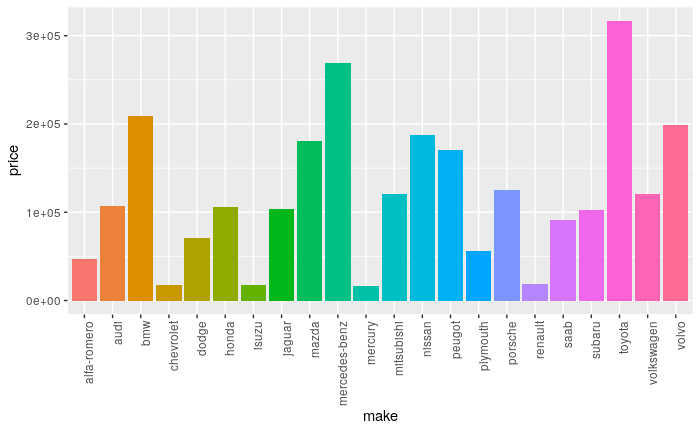

```r
ggplot(mob, aes(y = price, x = make, fill = make)) +
  geom_col() +
  theme(axis.text.x = element_text(angle = 90, hjust = 1)) +
  guides(fill = FALSE)
```

```r
NA
NA
```

### Vehicle Performance and Fuel Consumption

```r
mob$horsepower <- as.numeric(mob$horsepower)
```

```
NAs introduced by coercion
```

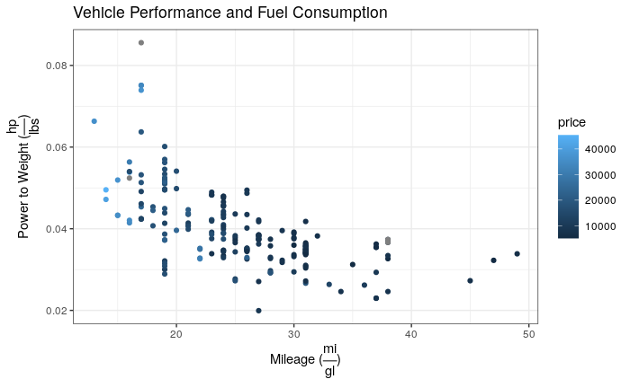

```r
ggplot(mob, aes(x = city.mpg, y = horsepower/curb.weight, col = price)) +
  geom_point() +
  theme_bw() +
  labs(x = TeX("Mileage (\\frac{mi}{gl})"), y = TeX("Power to Weight (\\frac{hp}{lbs})"),
       title = "Vehicle Performance and Fuel Consumption")
```

This indicates that high performance (High Power to Weight) vehicles tend to consume more fuel, this fuel change in fuel consumption appears to scale linearly.

## House Data

The housing data can be inspected using the `str` function and the information relating to the data set can be found [here](https://stat.ethz.ch/R-manual/R-devel/library/MASS/html/Boston.html)

```r
str(house)
```

```
'data.frame':   506 obs. of  14 variables:
 $ CRIM   : num  0.00632 0.02731 0.02729 0.03237 0.06905 ...
 $ ZN     : num  18 0 0 0 0 0 12.5 12.5 12.5 12.5 ...
 $ INDUS  : num  2.31 7.07 7.07 2.18 2.18 2.18 7.87 7.87 7.87 7.87 ...
 $ CHAS   : int  0 0 0 0 0 0 0 0 0 0 ...
 $ NOX    : num  0.538 0.469 0.469 0.458 0.458 0.458 0.524 0.524 0.524 0.524 ...
 $ RM     : num  6.58 6.42 7.18 7 7.15 ...
 $ AGE    : num  65.2 78.9 61.1 45.8 54.2 58.7 66.6 96.1 100 85.9 ...
 $ DIS    : num  4.09 4.97 4.97 6.06 6.06 ...
 $ RAD    : int  1 2 2 3 3 3 5 5 5 5 ...
 $ TAX    : num  296 242 242 222 222 222 311 311 311 311 ...
 $ PTRATIO: num  15.3 17.8 17.8 18.7 18.7 18.7 15.2 15.2 15.2 15.2 ...
 $ B      : num  397 397 393 395 397 ...
 $ LSTAT  : num  4.98 9.14 4.03 2.94 5.33 ...
 $ MEDV   : num  24 21.6 34.7 33.4 36.2 28.7 22.9 27.1 16.5 18.9 ...
```

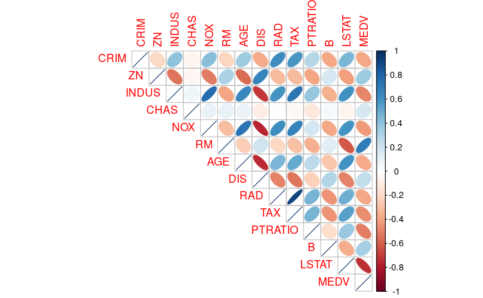

```r
library(GGally)
cor(house) %>% corrplot(method = "ellipse", type = 'upper')
```

This suggests that the median value of the house is signifanctly impacted by the number of rooms `RM` the lower status of the population `LSTAT` and the contentration of nitrous oxides in the air `NOX`, this could be visualised by a scatterplot:

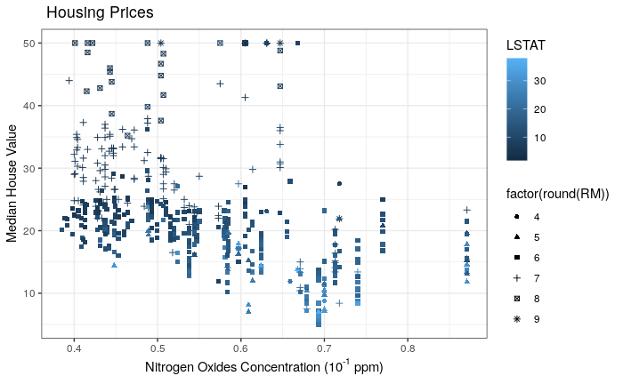

```r
ggplot(house, aes(x = NOX, y = MEDV, shape = factor(round(RM)), col = LSTAT))  +
  geom_point() +
  theme_bw() +
  labs(x = TeX("Nitrogen Oxides Concentration (10^{-1} ppm)"),
       y = "Median House Value",
       title = " Housing Prices")
```

# Question 3

```r
library("readxl")
(store <- read_excel("./10_data/10_data_Superstore.xls")) %>% str()
```

[output not shown]

```
tibble [9,994 × 21] (S3: tbl_df/tbl/data.frame)
 $ Row ID       : num [1:9994] 1 2 3 4 5 6 7 8 9 10 ...
 $ Order ID     : chr [1:9994] "CA-2013-152156" "CA-2013-152156" "CA-2013-138688" "US-2012-108966" ...
 $ Order Date   : POSIXct[1:9994], format: "2013-11-09" "2013-11-09" "2013-06-13" "2012-10-11" ...
 $ Ship Date    : POSIXct[1:9994], format: "2013-11-12" "2013-11-12" "2013-06-17" "2012-10-18" ...
 $ Ship Mode    : chr [1:9994] "Second Class" "Second Class" "Second Class" "Standard Class" ...
 $ Customer ID  : chr [1:9994] "CG-12520" "CG-12520" "DV-13045" "SO-20335" ...
 $ Customer Name: chr [1:9994] "Claire Gute" "Claire Gute" "Darrin Van Huff" "Sean O'Donnell" ...
 $ Segment      : chr [1:9994] "Consumer" "Consumer" "Corporate" "Consumer" ...
 $ Country      : chr [1:9994] "United States" "United States" "United States" "United States" ...
 $ City         : chr [1:9994] "Henderson" "Henderson" "Los Angeles" "Fort Lauderdale" ...
 $ State        : chr [1:9994] "Kentucky" "Kentucky" "California" "Florida" ...
 $ Postal Code  : num [1:9994] 42420 42420 90036 33311 33311 ...
 $ Region       : chr [1:9994] "South" "South" "West" "South" ...
 $ Product ID   : chr [1:9994] "FUR-BO-10001798" "FUR-CH-10000454" "OFF-LA-10000240" "FUR-TA-10000577" ...
 $ Category     : chr [1:9994] "Furniture" "Furniture" "Office Supplies" "Furniture" ...
 $ Sub-Category : chr [1:9994] "Bookcases" "Chairs" "Labels" "Tables" ...
 $ Product Name : chr [1:9994] "Bush Somerset Collection Bookcase" "Hon Deluxe Fabric Upholstered Stacking Chairs, Rounded Back" "Self-Adhesive Address Labels for Typewriters by Universal" "Bretford CR4500 Series Slim Rectangular Table" ...
 $ Sales        : num [1:9994] 262 731.9 14.6 957.6 22.4 ...
 $ Quantity     : num [1:9994] 2 3 2 5 2 7 4 6 3 5 ...
 $ Discount     : num [1:9994] 0 0 0 0.45 0.2 0 0 0.2 0.2 0 ...
 $ Profit       : num [1:9994] 41.91 219.58 6.87 -383.03 2.52 ...
```

```r
names(store)
```

```
 [1] "Row ID"        "Order ID"      "Order Date"    "Ship Date"     "Ship Mode"     "Customer ID"   "Customer Name" "Segment"       "Country"       "City"          "State"
[12] "Postal Code"   "Region"        "Product ID"    "Category"      "Sub-Category"  "Product Name"  "Sales"         "Quantity"      "Discount"      "Profit"
```

### Sales and Quantity

```r
store$Quantity <- factor(store$Quantity, levels = 1:max(store$Quantity), ordered = TRUE)
```

```
There were 26 warnings (use warnings() to see them)
```

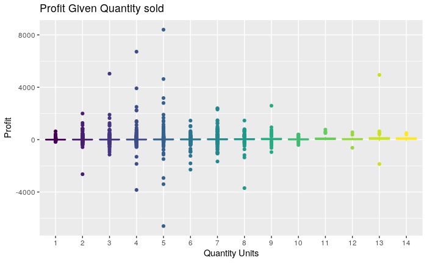

```r
p <- ggplot(data = store, aes(x = factor(Quantity), y = Profit, col = Quantity))



  p + geom_boxplot() +
  guides(col = FALSE) +
  labs(x = "Quantity Units", title = "Profit Given Quantity sold")
```

This suggests that 4/5 units of quantity produce the most variation in profit, for this reason it can be anticipated that higher quantities may be preferred because the profits will be more consistent.

## 2 Post Code and Profits

```r
names(store)
```

```
 [1] "Row ID"        "Order ID"      "Order Date"    "Ship Date"     "Ship Mode"     "Customer ID"   "Customer Name" "Segment"       "Country"       "City"          "State"
[12] "Postal Code"   "Region"        "Product ID"    "Category"      "Sub-Category"  "Product Name"  "Sales"         "Quantity"      "Discount"      "Profit"
```

```r
ggplot(store, aes(x = "", y = Profit, fill = Region)) +
  geom_bar(width = 1, stat = "identity") +
  coord_polar(theta = "y", start = 0)
```

[output not shown]

This shows that the South Region earns the most profits.

> Yeah, this is actually wrong, I’m not sure why TBH, I’m going to have to investigate Pie Charts in `ggplot2`, I didn’t realise it would be so poorly implemented.

## 3 “Region and Ship Mode”

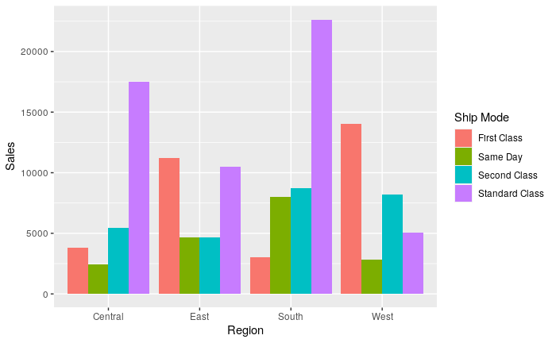

```r
ggplot(store, aes(x = Region, y = Sales, fill = `Ship Mode`)) +
  geom_col(position = 'dodge')
```